# R 기초 익히기

ksg

2015.11.24

## R기초익히기

### R의 편리한 기능들

- 스크립트 내용에서 crt-R / run
- 위아래 화살표로 앞에 입력한 코드 반복가능
- 도움말 기능 help(seq), ?seq, ??caret
- 내장 데이터의 활용 mtcars, iris
- 작업 디렉토리 확인 및 지정 getwd(), setwd(“d:/”)

### 1. R의 명령문

#### 할당 명령문 : = , <-, assign 을 사용하여 객체에 원소를 할당

```r
x<-c(1,2,3,4,5,6,7,8,9,10)
x
```

```
##  [1]  1  2  3  4  5  6  7  8  9 10
```

```r
assign("y", c(1,2,3,4,5,6,7,8,9,10))
y
```

```
##  [1]  1  2  3  4  5  6  7  8  9 10
```

```r
week = c('mon', 'tue', 'thu', 'wed', 'fri', 'sat', 'sun')
week
```

```
## [1] "mon" "tue" "thu" "wed" "fri" "sat" "sun"
```

#### 직접 명령문 : 함수, 연산자 등을 사용해 명령 실행

```r
25*3/13
```

```
## [1] 5.769231
```

```r
print ("hello world")
```

```
## [1] "hello world"
```

#### 참조문 : 코드에 대한 설명을 작성

```r
x = c(1, 2, 3) #해시를 사용하여 참조, 주석 사용
```

#### 함수와 인수

- 함수-특정 기능을 수행하는 명령문
- 인수-함수의 기능을 세밀하게 조정하는 옵션
- 표현형태-함수, 인수

```r
x<-c(1,2,3,4,5,6,7,8,9,10)
y<-c(1,2,3,4,5,6,7,8,9,10)
cor(x,y, method="pearson")
```

```
## [1] 1
```

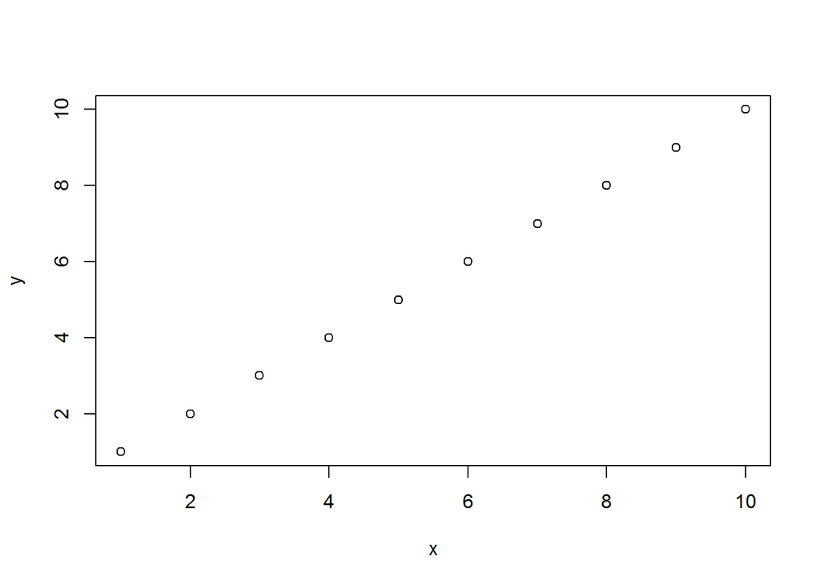

```r
plot(x,y)
```

### 2. R의 객체의 유형과 클래스

객체의 속성 - 유형(mode) : 객체가 포함하고 있는 데이터의 최소단위(수치형, 논리형, 복소수형, 문자형) - 특수형태 : NA(not available),NaN(not a number),Null(없음),Inf(무한대) - 객체의 길이 : length()함수로 확인

```r
mode(5+4)
```

```
## [1] "numeric"
```

```r
mode(5>4)
```

```
## [1] "logical"
```

```r
mode(2+5i)
```

```
## [1] "complex"
```

```r
mode("study")
```

```
## [1] "character"
```

```r
x<-c(1,2,3,4,NA)
is.na(x)
```

```
## [1] FALSE FALSE FALSE FALSE  TRUE
```

```r
length(x)
```

```
## [1] 5
```

- 클래스(class) : 데이터들의 배열혈태, 차원, 표현식에 따라 또다른 객체의 속성

```r
my.mat<-matrix(1:4, ncol=2) # 1~4로로 2열 행렬생성
my.mat
```

```
##      [,1] [,2]
## [1,]    1    3
## [2,]    2    4
```

```r
mode(my.mat)
```

```
## [1] "numeric"
```

```r
class(my.mat)
```

```
## [1] "matrix"
```

### 3. R의 데이터의 형태(벡터, 팩터, 행렬, 배열, 리스트, 데이터프레임)

#### 1) 벡터(vector)

- 1개이상의 원소를 갖는 1차원의 데이터
- 벡터를 생성할 때 seq, rep, norm 등의 함수를 사용하기도함

```r
A = c(1,2,3,4,5)
A
```

```
## [1] 1 2 3 4 5
```

```r
#seq(from,to,by,length.out) : 등차수열생성 함수
A = seq(from=1,to=5,by=1)
A
```

```
## [1] 1 2 3 4 5
```

```r
A = seq(1,10,0.5)
A
```

```
##  [1]  1.0  1.5  2.0  2.5  3.0  3.5  4.0  4.5  5.0  5.5  6.0  6.5  7.0  7.5
## [15]  8.0  8.5  9.0  9.5 10.0
```

```r
#rep(x,each,times,length.out) : 원소를 반복생성 하는 함수
B = rep(c(1,2,3),each=3,time=2)
B
```

```
##  [1] 1 1 1 2 2 2 3 3 3 1 1 1 2 2 2 3 3 3
```

```r
B = rep(A,each=2)
B
```

```
##  [1]  1.0  1.0  1.5  1.5  2.0  2.0  2.5  2.5  3.0  3.0  3.5  3.5  4.0  4.0
## [15]  4.5  4.5  5.0  5.0  5.5  5.5  6.0  6.0  6.5  6.5  7.0  7.0  7.5  7.5
## [29]  8.0  8.0  8.5  8.5  9.0  9.0  9.5  9.5 10.0 10.0
```

- 벡터의 원소를 추출하거나 추가 등 조작, []대괄호 연산자사용

```r
A<-seq(1,10,1)
A
```

```
##  [1]  1  2  3  4  5  6  7  8  9 10
```

```r
A[c(1,2,3)]    # 1,2,3번째추출
```

```
## [1] 1 2 3
```

```r
A[c(1:5)]      # 1~5번째 추출
```

```
## [1] 1 2 3 4 5
```

```r
A[2]<-100      # 2번째 원소에 100 덮어쓰기
append(A, 11, 100)
```

```
##  [1]   1 100   3   4   5   6   7   8   9  10  11
```

```r
A
```

```
##  [1]   1 100   3   4   5   6   7   8   9  10
```

#### 2) 팩터(factor)

- 1개이상의 원소를 갖는 1차원의 데이터
- 현상의 질이나 특성, 범주로 나눠지는 자료(순서형, 명목형)
- factor(x,levels,labels,ordered) / (객체,수준,수준의이름,순서형/명목형 전환)

```r
job<-c(1,2,3,1,2,3,1,2,3,1,2,3,1,2,3,1,2,3,1)
job.f<-factor(job,levels=c(1,2,3), labels=c("회사원","자영업","학생"))
job.f
```

```
##  [1] 회사원 자영업 학생   회사원 자영업 학생   회사원 자영업 학생   회사원
## [11] 자영업 학생   회사원 자영업 학생   회사원 자영업 학생   회사원
## Levels: 회사원 자영업 학생
```

```r
summary(job.f)
```

```
## 회사원 자영업   학생
##      7      6      6
```

#### 3) 행렬(matrix) : M행과 N열로 된 실수들의 사각형 배열(2차원배열)

- matrix(data,nrow,ncol,byrow,dimnames) / (데이터, 행수, 열수, F열방향입력T행방향입력, 각차원이름)

```r
matrix(c(1,2,3,4),ncol=2)
```

```
##      [,1] [,2]
## [1,]    1    3
## [2,]    2    4
```

```r
matrix(c(1,2,3,4),ncol=2,byrow=T)
```

```
##      [,1] [,2]
## [1,]    1    2
## [2,]    3    4
```

```r
matrix(1:4, nrow=2, dimnames=list(c("row1","row2"), c("col1", "col2")))
```

```
##      col1 col2
## row1    1    3
## row2    2    4
```

- 행을 합쳐서 행렬만들기

```r
row1=c(1,2,3)
row2=c(1,2,3)
row3=c(1,2,3)
mat = rbind(row1,row2,row3)
```

- 열을 합쳐서 행렬만들기

```r
col1=c(1,2,3)
col2=c(1,2,3)
col3=c(1,2,3)
mat=cbind(col1,col2,col3)
mat
```

```
##      col1 col2 col3
## [1,]    1    1    1
## [2,]    2    2    2
## [3,]    3    3    3
```

- 행렬원소 조작

```r
mat[3,]  #3행 전체원소
```

```
## col1 col2 col3
##    3    3    3
```

```r
mat[3,3] #3행 3열의 원소
```

```
## col3
##    3
```

```r
mat[-2,] #2행 빼고 전체원소
```

```
##      col1 col2 col3
## [1,]    1    1    1
## [2,]    3    3    3
```

#### 4) 배열 array : 3차원으로 구성된 형태의 자료

- array(data,dim,dimnames)

```r
asia<-array(1:18,dim=c(3,3,2),
            dimnames=list(c("한국","중국","일본"),
                          c("물가","행복도","인구밀도"),c("2013","2014")))
asia
```

```
## , , 2013
##
##      물가 행복도 인구밀도
## 한국    1      4        7
## 중국    2      5        8
## 일본    3      6        9
##
## , , 2014
##
##      물가 행복도 인구밀도
## 한국   10     13       16
## 중국   11     14       17
## 일본   12     15       18
```

- 배열조작

```r
asia[1,,]
```

```
##          2013 2014
## 물가        1   10
## 행복도      4   13
## 인구밀도    7   16
```

```r
asia[,-2,]
```

```
## , , 2013
##
##      물가 인구밀도
## 한국    1        7
## 중국    2        8
## 일본    3        9
##
## , , 2014
##
##      물가 인구밀도
## 한국   10       16
## 중국   11       17
## 일본   12       18
```

```r
asia[,,1]
```

```
##      물가 행복도 인구밀도
## 한국    1      4        7
## 중국    2      5        8
## 일본    3      6        9
```

#### 5) 리스트 : 길이와 성분이 다른 여러유형을 가진 데이터형태

- list(name=data,….)

```r
one<-"빅데이터와 R"
two<-c("하나","둘","셋","넷","다섯")
three <-c(1,2,3)
list1<-list(first=one, second=two, third=three)
list1
```

```
## $first
## [1] "빅데이터와 R"
##
## $second
## [1] "하나" "둘"   "셋"   "넷"   "다섯"
##
## $third
## [1] 1 2 3
```

- 리스트 조작

```r
list1[[1]]    #첫번째 성분
```

```
## [1] "빅데이터와 R"
```

```r
list1[[3]][1] #세번째 성분 첫번째 원소
```

```
## [1] 1
```

- 성분이름으로 추출

```r
list1$second
```

```
## [1] "하나" "둘"   "셋"   "넷"   "다섯"
```

```r
list1$second[3]
```

```
## [1] "셋"
```

- 성분추가

```r
ten = c(1,2,3,4,5,6,7,8,9,10)     #임의 자료 생성
list1[[4]] = ten
list1
```

```
## $first
## [1] "빅데이터와 R"
##
## $second
## [1] "하나" "둘"   "셋"   "넷"   "다섯"
##
## $third
## [1] 1 2 3
##
## [[4]]
##  [1]  1  2  3  4  5  6  7  8  9 10
```

```r
names(list1)[[4]] = "forth"
list1
```

```
## $first
## [1] "빅데이터와 R"
##
## $second
## [1] "하나" "둘"   "셋"   "넷"   "다섯"
##
## $third
## [1] 1 2 3
##
## $forth
##  [1]  1  2  3  4  5  6  7  8  9 10
```

- 성분삭제

```r
list1[[4]] = NULL
list1
```

```
## $first
## [1] "빅데이터와 R"
##
## $second
## [1] "하나" "둘"   "셋"   "넷"   "다섯"
##
## $third
## [1] 1 2 3
```

#### 6) 데이터 프레임(dataframe)

- 길이가 동일한 여러개의 벡터로 구성된 데이터
- data.frame(변수, header, row.names,stringsAsFactors, )

```r
id = c("철수", "영수","영희", "숙희")
history = c(80, 60, 70, 90)
math = c(50, 50, 50, 80)
grade = data.frame(history, math, row.names=id)
```

- 데이터프레임 조작(행, 열 순서)

```r
grade[1,]
```

```
##      history math
## 철수      80   50
```

```r
grade[,2]
```

```
## [1] 50 50 50 80
```

```r
grade[[1]][1]
```

```
## [1] 80
```

```r
grade[grade[[1]]>60, ]
```

```
##      history math
## 철수      80   50
## 영희      70   50
## 숙희      90   80
```

- 데이터프레임 조작(변수명)

```r
grade$history
```

```
## [1] 80 60 70 90
```

```r
grade$math
```

```
## [1] 50 50 50 80
```

```r
grade[grade$math>50,]
```

```
##      history math
## 숙희      90   80
```

### 4. 내장데이터로 실습해보기

```r
mtcars
```

```
##                      mpg cyl  disp  hp drat    wt  qsec vs am gear carb
## Mazda RX4           21.0   6 160.0 110 3.90 2.620 16.46  0  1    4    4
## Mazda RX4 Wag       21.0   6 160.0 110 3.90 2.875 17.02  0  1    4    4
## Datsun 710          22.8   4 108.0  93 3.85 2.320 18.61  1  1    4    1
## Hornet 4 Drive      21.4   6 258.0 110 3.08 3.215 19.44  1  0    3    1
## Hornet Sportabout   18.7   8 360.0 175 3.15 3.440 17.02  0  0    3    2
## Valiant             18.1   6 225.0 105 2.76 3.460 20.22  1  0    3    1
## Duster 360          14.3   8 360.0 245 3.21 3.570 15.84  0  0    3    4
## Merc 240D           24.4   4 146.7  62 3.69 3.190 20.00  1  0    4    2
## Merc 230            22.8   4 140.8  95 3.92 3.150 22.90  1  0    4    2
## Merc 280            19.2   6 167.6 123 3.92 3.440 18.30  1  0    4    4
## Merc 280C           17.8   6 167.6 123 3.92 3.440 18.90  1  0    4    4
## Merc 450SE          16.4   8 275.8 180 3.07 4.070 17.40  0  0    3    3
## Merc 450SL          17.3   8 275.8 180 3.07 3.730 17.60  0  0    3    3
## Merc 450SLC         15.2   8 275.8 180 3.07 3.780 18.00  0  0    3    3
## Cadillac Fleetwood  10.4   8 472.0 205 2.93 5.250 17.98  0  0    3    4
## Lincoln Continental 10.4   8 460.0 215 3.00 5.424 17.82  0  0    3    4
## Chrysler Imperial   14.7   8 440.0 230 3.23 5.345 17.42  0  0    3    4
## Fiat 128            32.4   4  78.7  66 4.08 2.200 19.47  1  1    4    1
## Honda Civic         30.4   4  75.7  52 4.93 1.615 18.52  1  1    4    2
## Toyota Corolla      33.9   4  71.1  65 4.22 1.835 19.90  1  1    4    1
## Toyota Corona       21.5   4 120.1  97 3.70 2.465 20.01  1  0    3    1
## Dodge Challenger    15.5   8 318.0 150 2.76 3.520 16.87  0  0    3    2
## AMC Javelin         15.2   8 304.0 150 3.15 3.435 17.30  0  0    3    2
## Camaro Z28          13.3   8 350.0 245 3.73 3.840 15.41  0  0    3    4
## Pontiac Firebird    19.2   8 400.0 175 3.08 3.845 17.05  0  0    3    2
## Fiat X1-9           27.3   4  79.0  66 4.08 1.935 18.90  1  1    4    1
## Porsche 914-2       26.0   4 120.3  91 4.43 2.140 16.70  0  1    5    2
## Lotus Europa        30.4   4  95.1 113 3.77 1.513 16.90  1  1    5    2
## Ford Pantera L      15.8   8 351.0 264 4.22 3.170 14.50  0  1    5    4
## Ferrari Dino        19.7   6 145.0 175 3.62 2.770 15.50  0  1    5    6
## Maserati Bora       15.0   8 301.0 335 3.54 3.570 14.60  0  1    5    8
## Volvo 142E          21.4   4 121.0 109 4.11 2.780 18.60  1  1    4    2
```

```r
# names, str, summary, attributes 함수로 데이터 이해하기
# 일부 변수만 추출하기([], $사용)
# 특정 조건 hp가 3사100이상인 차량만 추출
# 일부 변수로 새로운 데이터프레임 만들기
```

### 5. 데이터 입출력

- setwd : 워크 디렉토리설정
- txt파일 : read.table(file, header, sep, row.names, col.names, na.strings, stringAsFactors)

```r
#워크폴더, txt파일만들기
setwd("C:/Users/user/Desktop/GN_1")
table = read.table("readtable.txt")
table
```

```
##   V1 V2 V3 V4 V5 V6 V7 V8 V9
## 1  1  2  3  4  5  6  7  8  9
## 2  1  2  3  4  5  6  7  8  9
## 3  1  2  3  4  5  6  7  8  9
## 4  1  2  3  4  5  6  7  8  9
## 5  1  2  3  4  5  6  7  8  9
```

- csv파일 : read.csv(상기동일)

```r
setwd("C:/Users/user/Desktop/GN_1")
csv = read.csv("csv.csv")
csv
```

```
##   ID var1 var2 var3   var4
## 1  1    1   NA    1      R
## 2  2    2   NA    2      R
## 3  3    3    3    3      R
## 4  4    4    4    4 python
## 5  5   NA    5    5 python
## 6  6    6    6   NA python
## 7  7    7    7    7 python
```

```r
str(csv)
```

```
## 'data.frame':    7 obs. of  5 variables:
##  $ ID  : int  1 2 3 4 5 6 7
##  $ var1: int  1 2 3 4 NA 6 7
##  $ var2: int  NA NA 3 4 5 6 7
##  $ var3: int  1 2 3 4 5 NA 7
##  $ var4: Factor w/ 2 levels "python","R": 2 2 2 1 1 1 1
```

```r
setwd("C:/Users/user/Desktop/GN_1")
csv = read.csv("csv.csv", header = FALSE)
csv       #첫행도 데이터로 읽음
```

```
##   V1   V2   V3   V4     V5
## 1 ID var1 var2 var3   var4
## 2  1    1 <NA>    1      R
## 3  2    2 <NA>    2      R
## 4  3    3    3    3      R
## 5  4    4    4    4 python
## 6  5 <NA>    5    5 python
## 7  6    6    6      python
## 8  7    7    7    7 python
```

```r
setwd("C:/Users/user/Desktop/GN_1")
csv = read.csv("csv.csv", na.strings = c(NA,""))
csv       #""->NA
```

```
##   ID var1 var2 var3   var4
## 1  1    1   NA    1      R
## 2  2    2   NA    2      R
## 3  3    3    3    3      R
## 4  4    4    4    4 python
## 5  5   NA    5    5 python
## 6  6    6    6   NA python
## 7  7    7    7    7 python
```

```r
setwd("C:/Users/user/Desktop/GN_1")
csv = read.csv("csv.csv", stringsAsFactors = FALSE)
str(csv)  #fact->char
```

```
## 'data.frame':    7 obs. of  5 variables:
##  $ ID  : int  1 2 3 4 5 6 7
##  $ var1: int  1 2 3 4 NA 6 7
##  $ var2: int  NA NA 3 4 5 6 7
##  $ var3: int  1 2 3 4 5 NA 7
##  $ var4: chr  "R" "R" "R" "python" ...
```

```r
attributes(csv)  #데이터프레임
```

```
## $names
## [1] "ID"   "var1" "var2" "var3" "var4"
##
## $class
## [1] "data.frame"
##
## $row.names
## [1] 1 2 3 4 5 6 7
```

- 데이터 저장하기

```r
write.table(csv, file="write.csv", row.names = T, col.names = T)
```